#### Joseph O'Malley

11/21/2018

# Heart disease mortality rate prediction

```python
%%javascript
$.getScript('https://kmahelona.github.io/ipython_notebook_goodies/ipython_notebook_toc.js')
```

### Predicting Heart Disease

Using a Microsoft Data Science Capstone dataset from kaggle: https://www.kaggle.com/nandvard/microsoft-data-science-capstone/homeit

The goal is to predict the rate of heart disease (per 100,000 individuals) across the United States at the county-level from other socioeconomic indicators. The data is compiled from a wide range of sources and made publicly available by the United States Department of Agriculture Economic Research Service (USDA ERS).

There are 33 variables and 3198 rows in this dataset. Each row in the dataset represents a United States county.

We're trying to predict the variable heart_disease_mortality_per_100k (a positive integer) for each row of the test data set.

#### Load in Data

```python
## load in headers data and display data frame

# import module(s) into namespace
import pandas as pd #we almost always need pandas because we like data frames
import numpy as np
pd.set_option('display.max_colwidth', 150) #important for getting all the text

##load in names
c_features=pd.read_csv('/Users/ultrajosef/Downloads/Macbook 2012 Files/BIA6303/data/heart_features.csv'
              ,sep = ",")
## check shape of data imported
c_features.shape
#c_features.head()
```

```
(3198, 34)
```

```python
##load in names
c_labels=pd.read_csv('/Users/ultrajosef/Downloads/Macbook 2012 Files/BIA6303/data/heart_labels.csv'
              ,sep = ",")
## check shape of data imported
print (c_labels.shape)
# c_labels.head()
# print (c_labels['row_id'].dtypes)
# print (c_features['row_id'].dtypes)
```

```
(3198, 2)
```

```python
## merge data on unique row_id
c = pd.merge(c_labels, c_features, how="inner", on="row_id")

## check shape of data imported
c.shape
```

```
(3198, 35)
```

```python
# drop
c=c.drop(['row_id', 'yr'], axis=1)

# view combined pandas dataframe
c.head()
```

|  | heart_disease_mortality_per_100k | area__rucc | area__urban_influence | econ__economic_typology | econ__pct_civilian_labor | econ__pct_unemployment | econ__pct_uninsured_adults | econ__pct_uninsured_children | demo__pct_female | demo__pct_below_18_years_of_age | ... | health__pct_adult_smoking | health__pct_diabetes | health__pct_low_birthweight | health__pct_excessive_drinking | health__pct_physical_inacticity | health__air_pollution_particulate_matter | health__homicides_per_100k | health__motor_vehicle_crash_deaths_per_100k | health__pop_per_dentist | health__pop_per_primary_care_physician |
| --- | --- | --- | --- | --- | --- | --- | --- | --- | --- | --- | --- | --- | --- | --- | --- | --- | --- | --- | --- | --- | --- |
| 0 | 312 | Metro - Counties in metro areas of fewer than 250,000 population | Small-in a metro area with fewer than 1 million residents | Manufacturing-dependent | 0.408 | 0.057 | 0.254 | 0.066 | 0.516 | 0.235 | ... | 0.230 | 0.131 | 0.089 | nan | 0.332 | 13.000 | 2.800 | 15.090 | 1650.000 | 1489.000 |
| 1 | 257 | Metro - Counties in metro areas of fewer than 250,000 population | Small-in a metro area with fewer than 1 million residents | Mining-dependent | 0.556 | 0.039 | 0.260 | 0.143 | 0.503 | 0.272 | ... | 0.190 | 0.090 | 0.082 | 0.181 | 0.265 | 10.000 | 2.300 | 19.790 | 2010.000 | 2480.000 |
| 2 | 195 | Metro - Counties in metro areas of 1 million population or more | Large-in a metro area with at least 1 million residents or more | Nonspecialized | 0.541 | 0.057 | 0.070 | 0.023 | 0.522 | 0.179 | ... | 0.156 | 0.084 | 0.098 | 0.195 | 0.209 | 10.000 | 9.310 | 3.140 | 629.000 | 690.000 |
| 3 | 218 | Nonmetro - Urban population of 2,500 to 19,999, adjacent to a metro area | Noncore adjacent to a small metro with town of at least 2,500 residents | Nonspecialized | 0.500 | 0.061 | 0.203 | 0.059 | 0.525 | 0.200 | ... | nan | 0.104 | 0.058 | nan | 0.238 | 13.000 | nan | nan | 1810.000 | 6630.000 |
| 4 | 355 | Nonmetro - Urban population of 2,500 to 19,999, not adjacent to a metro area | Noncore not adjacent to a metro/micro area and contains a town of 2,500 or more residents | Nonspecialized | 0.471 | 0.050 | 0.225 | 0.103 | 0.511 | 0.237 | ... | 0.234 | 0.137 | 0.070 | 0.194 | 0.290 | 9.000 | nan | 29.390 | 3489.000 | 2590.000 |

5 rows × 33 columns

# Exploratory Data Analysis

```python
## check datatypes
c.dtypes
```

```
heart_disease_mortality_per_100k                      int64
area__rucc                                           object
area__urban_influence                                object
econ__economic_typology                              object
econ__pct_civilian_labor                            float64
econ__pct_unemployment                              float64
econ__pct_uninsured_adults                          float64
econ__pct_uninsured_children                        float64
demo__pct_female                                    float64
demo__pct_below_18_years_of_age                     float64
demo__pct_aged_65_years_and_older                   float64
demo__pct_hispanic                                  float64
demo__pct_non_hispanic_african_american             float64
demo__pct_non_hispanic_white                        float64
demo__pct_american_indian_or_alaskan_native         float64
demo__pct_asian                                     float64
demo__pct_adults_less_than_a_high_school_diploma    float64
demo__pct_adults_with_high_school_diploma           float64
demo__pct_adults_with_some_college                  float64
demo__pct_adults_bachelors_or_higher                float64
demo__birth_rate_per_1k                               int64
demo__death_rate_per_1k                               int64
health__pct_adult_obesity                           float64
health__pct_adult_smoking                           float64
health__pct_diabetes                                float64
health__pct_low_birthweight                         float64
health__pct_excessive_drinking                      float64
health__pct_physical_inacticity                     float64
health__air_pollution_particulate_matter            float64
health__homicides_per_100k                          float64
health__motor_vehicle_crash_deaths_per_100k         float64
health__pop_per_dentist                             float64
health__pop_per_primary_care_physician              float64
dtype: object
```

```python
## look at unique counts for catagorical features
## area__rucc
pd.value_counts(c['area__rucc'])
```

```
Nonmetro - Urban population of 2,500 to 19,999, adjacent to a metro area                         608
Nonmetro - Completely rural or less than 2,500 urban population, not adjacent to a metro area    484
Metro - Counties in metro areas of 1 million population or more                                  436
Nonmetro - Urban population of 2,500 to 19,999, not adjacent to a metro area                     418
Metro - Counties in metro areas of 250,000 to 1 million population                               370
Metro - Counties in metro areas of fewer than 250,000 population                                 322
Nonmetro - Completely rural or less than 2,500 urban population, adjacent to a metro area        238
Nonmetro - Urban population of 20,000 or more, adjacent to a metro area                          222
Nonmetro - Urban population of 20,000 or more, not adjacent to a metro area                      100
Name: area__rucc, dtype: int64
```

```python
## look at unique counts for catagorical features
## area__urban_influence
pd.value_counts(c['area__urban_influence'])
```

```
Small-in a metro area with fewer than 1 million residents                                             692
Large-in a metro area with at least 1 million residents or more                                       436
Noncore adjacent to a small metro with town of at least 2,500 residents                               346
Micropolitan adjacent to a small metro area                                                           262
Micropolitan not adjacent to a metro area                                                             254
Noncore not adjacent to a metro/micro area and does not contain a town of at least 2,500 residents    210
Noncore adjacent to micro area and does not contain a town of at least 2,500 residents                210
Noncore adjacent to micro area and contains a town of 2,500-19,999 residents                          206
Noncore adjacent to a small metro and does not contain a town of at least 2,500 residents             176
Noncore adjacent to a large metro area                                                                158
Micropolitan adjacent to a large metro area                                                           126
Noncore not adjacent to a metro/micro area and contains a town of 2,500  or more residents            122
Name: area__urban_influence, dtype: int64
```

```python
## look at unique counts for catagorical features
## econ__economic_typology

pd.value_counts(c['econ__economic_typology'])
```

```
Nonspecialized                        1266
Manufacturing-dependent                494
Farm-dependent                         482
Federal/State government-dependent     390
Recreation                             312
Mining-dependent                       254
Name: econ__economic_typology, dtype: int64
```

```python
## Remove columns with over 50 percent of data missing
print(c.shape)
c = c[c.astype('bool').mean(axis=1)>=0.50]
print(c.shape)
```

```
(3198, 33)
(3198, 33)
```

```python
### Replace nulls with median
c.fillna((c.median()), inplace=True)

## check distribution of numeric columns
c.describe()
```

|  | heart_disease_mortality_per_100k | econ__pct_civilian_labor | econ__pct_unemployment | econ__pct_uninsured_adults | econ__pct_uninsured_children | demo__pct_female | demo__pct_below_18_years_of_age | demo__pct_aged_65_years_and_older | demo__pct_hispanic | demo__pct_non_hispanic_african_american | ... | health__pct_adult_smoking | health__pct_diabetes | health__pct_low_birthweight | health__pct_excessive_drinking | health__pct_physical_inacticity | health__air_pollution_particulate_matter | health__homicides_per_100k | health__motor_vehicle_crash_deaths_per_100k | health__pop_per_dentist | health__pop_per_primary_care_physician |
| --- | --- | --- | --- | --- | --- | --- | --- | --- | --- | --- | --- | --- | --- | --- | --- | --- | --- | --- | --- | --- | --- |
| count | 3198.000 | 3198.000 | 3198.000 | 3198.000 | 3198.000 | 3198.000 | 3198.000 | 3198.000 | 3198.000 | 3198.000 | ... | 3198.000 | 3198.000 | 3198.000 | 3198.000 | 3198.000 | 3198.000 | 3198.000 | 3198.000 | 3198.000 | 3198.000 |
| mean | 279.369 | 0.467 | 0.060 | 0.217 | 0.086 | 0.499 | 0.228 | 0.170 | 0.090 | 0.091 | ... | 0.213 | 0.109 | 0.084 | 0.165 | 0.277 | 11.629 | 5.180 | 20.937 | 3374.864 | 2511.615 |
| std | 58.953 | 0.074 | 0.023 | 0.067 | 0.040 | 0.024 | 0.034 | 0.044 | 0.143 | 0.147 | ... | 0.058 | 0.023 | 0.022 | 0.042 | 0.053 | 1.552 | 3.180 | 9.791 | 2477.287 | 2028.520 |
| min | 109.000 | 0.207 | 0.010 | 0.046 | 0.012 | 0.278 | 0.092 | 0.045 | 0.000 | 0.000 | ... | 0.046 | 0.032 | 0.033 | 0.038 | 0.090 | 7.000 | -0.400 | 3.140 | 339.000 | 189.000 |
| 25% | 237.000 | 0.420 | 0.044 | 0.166 | 0.057 | 0.493 | 0.206 | 0.141 | 0.019 | 0.006 | ... | 0.179 | 0.094 | 0.069 | 0.146 | 0.243 | 10.000 | 4.700 | 14.523 | 1879.000 | 1462.250 |
| 50% | 275.000 | 0.468 | 0.057 | 0.216 | 0.077 | 0.503 | 0.226 | 0.167 | 0.035 | 0.022 | ... | 0.210 | 0.109 | 0.081 | 0.164 | 0.280 | 12.000 | 4.700 | 19.630 | 2690.000 | 1999.000 |
| 75% | 317.000 | 0.514 | 0.072 | 0.261 | 0.106 | 0.512 | 0.246 | 0.195 | 0.087 | 0.096 | ... | 0.242 | 0.124 | 0.094 | 0.182 | 0.313 | 13.000 | 4.700 | 25.220 | 3889.000 | 2749.000 |
| max | 512.000 | 1.000 | 0.248 | 0.496 | 0.281 | 0.573 | 0.417 | 0.346 | 0.932 | 0.858 | ... | 0.513 | 0.203 | 0.238 | 0.367 | 0.442 | 15.000 | 50.490 | 110.450 | 28130.000 | 23399.000 |

8 rows × 30 columns

#### Boxplot

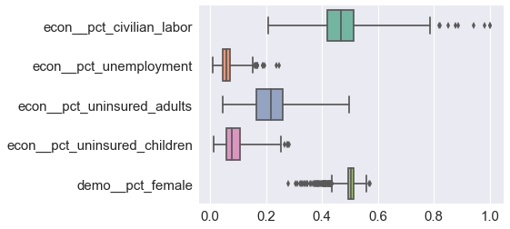

```python
## check distribution of features
import matplotlib.pyplot as plt

## look for outliers using boxplots
np.random.seed(1234)

## get full list of features
# list(c)

## subset list for visualization
c4plt = c.loc[:, 'area__rucc':'demo__pct_female']
ax = sns.boxplot(data=c4plt, orient="h", palette="Set2", whis=3.0)
```

```python
## Convert catagorical columns to unique column for each value type for the models to handle
#Dummies via Pandas

area__rucc_dummies = pd.DataFrame(pd.get_dummies(c['area__rucc']))
area__urban_influence_dummies = pd.DataFrame(pd.get_dummies(c['area__urban_influence']))
econ__economic_typology_dummies = pd.DataFrame(pd.get_dummies(c['econ__economic_typology']))


## join dummied variables to main df
c = pd.concat([c, area__rucc_dummies, area__urban_influence_dummies
              ,econ__economic_typology_dummies], axis=1)

## drop columns that have been dummied
c=c.drop(['area__rucc', 'area__urban_influence', 'econ__economic_typology'], axis=1)

## view data
c.head(5)
```

|  | heart_disease_mortality_per_100k | econ__pct_civilian_labor | econ__pct_unemployment | econ__pct_uninsured_adults | econ__pct_uninsured_children | demo__pct_female | demo__pct_below_18_years_of_age | demo__pct_aged_65_years_and_older | demo__pct_hispanic | demo__pct_non_hispanic_african_american | ... | Noncore adjacent to micro area and does not contain a town of at least 2,500 residents | Noncore not adjacent to a metro/micro area and contains a town of 2,500 or more residents | Noncore not adjacent to a metro/micro area and does not contain a town of at least 2,500 residents | Small-in a metro area with fewer than 1 million residents | Farm-dependent | Federal/State government-dependent | Manufacturing-dependent | Mining-dependent | Nonspecialized | Recreation |
| --- | --- | --- | --- | --- | --- | --- | --- | --- | --- | --- | --- | --- | --- | --- | --- | --- | --- | --- | --- | --- | --- |
| 0 | 312 | 0.408 | 0.057 | 0.254 | 0.066 | 0.516 | 0.235 | 0.176 | 0.109 | 0.039 | ... | 0 | 0 | 0 | 1 | 0 | 0 | 1 | 0 | 0 | 0 |
| 1 | 257 | 0.556 | 0.039 | 0.260 | 0.143 | 0.503 | 0.272 | 0.101 | 0.410 | 0.070 | ... | 0 | 0 | 0 | 1 | 0 | 0 | 0 | 1 | 0 | 0 |
| 2 | 195 | 0.541 | 0.057 | 0.070 | 0.023 | 0.522 | 0.179 | 0.115 | 0.202 | 0.198 | ... | 0 | 0 | 0 | 0 | 0 | 0 | 0 | 0 | 1 | 0 |
| 3 | 218 | 0.500 | 0.061 | 0.203 | 0.059 | 0.525 | 0.200 | 0.164 | 0.013 | 0.049 | ... | 0 | 0 | 0 | 0 | 0 | 0 | 0 | 0 | 1 | 0 |
| 4 | 355 | 0.471 | 0.050 | 0.225 | 0.103 | 0.511 | 0.237 | 0.171 | 0.025 | 0.008 | ... | 0 | 1 | 0 | 0 | 0 | 0 | 0 | 0 | 1 | 0 |

5 rows × 57 columns

#### Look for highly correlated features to remove from model

```python
# ## check datatypes (optional)
# c.dtypes

## check correlation of features
import matplotlib.pyplot as plt

##set options so correlation outputs as float, with 3 figs after the decimal
pd.set_option('display.float_format', lambda x: '%.3f' % x)
c.corr()
```

|  | heart_disease_mortality_per_100k | econ__pct_civilian_labor | econ__pct_unemployment | econ__pct_uninsured_adults | econ__pct_uninsured_children | demo__pct_female | demo__pct_below_18_years_of_age | demo__pct_aged_65_years_and_older | demo__pct_hispanic | demo__pct_non_hispanic_african_american | ... | Noncore adjacent to micro area and does not contain a town of at least 2,500 residents | Noncore not adjacent to a metro/micro area and contains a town of 2,500 or more residents | Noncore not adjacent to a metro/micro area and does not contain a town of at least 2,500 residents | Small-in a metro area with fewer than 1 million residents | Farm-dependent | Federal/State government-dependent | Manufacturing-dependent | Mining-dependent | Nonspecialized | Recreation |
| --- | --- | --- | --- | --- | --- | --- | --- | --- | --- | --- | --- | --- | --- | --- | --- | --- | --- | --- | --- | --- | --- |
| heart_disease_mortality_per_100k | 1.000 | -0.477 | 0.372 | 0.334 | -0.034 | 0.087 | 0.122 | -0.056 | -0.112 | 0.376 | ... | -0.022 | -0.061 | -0.098 | -0.070 | -0.146 | -0.008 | 0.114 | 0.109 | 0.104 | -0.226 |
| econ__pct_civilian_labor | -0.477 | 1.000 | -0.619 | -0.407 | -0.028 | 0.110 | -0.014 | 0.005 | 0.005 | -0.344 | ... | 0.074 | 0.066 | 0.089 | 0.004 | 0.216 | -0.168 | -0.007 | 0.034 | -0.069 | 0.016 |
| econ__pct_unemployment | 0.372 | -0.619 | 1.000 | 0.272 | -0.104 | 0.071 | 0.005 | -0.050 | -0.024 | 0.381 | ... | -0.084 | -0.031 | -0.060 | -0.018 | -0.295 | 0.105 | 0.025 | -0.051 | 0.104 | 0.084 |
| econ__pct_uninsured_adults | 0.334 | -0.407 | 0.272 | 1.000 | 0.718 | -0.076 | 0.280 | -0.076 | 0.478 | 0.206 | ... | 0.037 | 0.036 | 0.064 | -0.089 | 0.027 | 0.017 | -0.042 | 0.167 | -0.057 | -0.058 |
| econ__pct_uninsured_children | -0.034 | -0.028 | -0.104 | 0.718 | 1.000 | -0.211 | 0.184 | 0.084 | 0.442 | -0.103 | ... | 0.155 | 0.081 | 0.206 | -0.153 | 0.234 | -0.010 | -0.112 | 0.222 | -0.221 | 0.028 |
| demo__pct_female | 0.087 | 0.110 | 0.071 | -0.076 | -0.211 | 1.000 | 0.198 | 0.107 | -0.162 | 0.098 | ... | -0.076 | -0.102 | -0.034 | 0.123 | -0.051 | -0.247 | 0.074 | -0.137 | 0.214 | 0.016 |
| demo__pct_below_18_years_of_age | 0.122 | -0.014 | 0.005 | 0.280 | 0.184 | 0.198 | 1.000 | -0.566 | 0.321 | 0.022 | ... | -0.070 | 0.012 | -0.052 | 0.034 | 0.004 | -0.135 | 0.087 | 0.098 | 0.138 | -0.278 |
| demo__pct_aged_65_years_and_older | -0.056 | 0.005 | -0.050 | -0.076 | 0.084 | 0.107 | -0.566 | 1.000 | -0.245 | -0.225 | ... | 0.220 | -0.010 | 0.257 | -0.193 | 0.328 | -0.159 | -0.059 | -0.090 | -0.202 | 0.268 |
| demo__pct_hispanic | -0.112 | 0.005 | -0.024 | 0.478 | 0.442 | -0.162 | 0.321 | -0.245 | 1.000 | -0.106 | ... | -0.037 | 0.043 | -0.024 | -0.046 | -0.006 | 0.060 | -0.080 | 0.206 | -0.050 | -0.067 |
| demo__pct_non_hispanic_african_american | 0.376 | -0.344 | 0.381 | 0.206 | -0.103 | 0.098 | 0.022 | -0.225 | -0.106 | 1.000 | ... | -0.100 | -0.078 | -0.133 | 0.038 | -0.178 | 0.117 | 0.003 | -0.086 | 0.172 | -0.123 |
| demo__pct_non_hispanic_white | -0.158 | 0.272 | -0.318 | -0.553 | -0.296 | 0.066 | -0.372 | 0.443 | -0.607 | -0.594 | ... | 0.104 | -0.018 | 0.057 | 0.017 | 0.136 | -0.168 | 0.087 | -0.096 | -0.080 | 0.135 |
| demo__pct_american_indian_or_alaskan_native | 0.005 | -0.135 | 0.190 | 0.245 | 0.203 | -0.067 | 0.339 | -0.174 | -0.014 | -0.102 | ... | 0.012 | 0.111 | 0.164 | -0.070 | 0.044 | 0.076 | -0.060 | 0.068 | -0.068 | -0.014 |
| demo__pct_asian | -0.267 | 0.176 | -0.089 | -0.107 | -0.089 | 0.011 | 0.017 | -0.319 | 0.170 | 0.021 | ... | -0.095 | 0.005 | -0.089 | 0.080 | -0.138 | 0.072 | -0.046 | -0.069 | 0.135 | -0.017 |
| demo__pct_adults_less_than_a_high_school_diploma | 0.527 | -0.521 | 0.418 | 0.663 | 0.282 | -0.133 | 0.221 | -0.141 | 0.437 | 0.354 | ... | -0.020 | -0.047 | -0.028 | -0.124 | -0.055 | 0.031 | 0.084 | 0.156 | -0.006 | -0.202 |
| demo__pct_adults_with_high_school_diploma | 0.428 | -0.222 | 0.188 | 0.030 | -0.079 | -0.106 | -0.116 | 0.304 | -0.318 | -0.046 | ... | 0.061 | -0.011 | 0.016 | -0.140 | 0.061 | -0.116 | 0.222 | 0.030 | -0.077 | -0.117 |
| demo__pct_adults_with_some_college | -0.341 | 0.240 | -0.237 | -0.236 | 0.040 | 0.012 | 0.044 | 0.135 | -0.100 | -0.255 | ... | 0.037 | 0.082 | 0.101 | 0.082 | 0.163 | -0.024 | -0.107 | -0.040 | -0.071 | 0.113 |
| demo__pct_adults_bachelors_or_higher | -0.541 | 0.433 | -0.329 | -0.392 | -0.176 | 0.178 | -0.102 | -0.211 | -0.024 | -0.085 | ... | -0.055 | -0.003 | -0.051 | 0.157 | -0.102 | 0.082 | -0.177 | -0.119 | 0.107 | 0.180 |
| demo__birth_rate_per_1k | 0.142 | -0.004 | -0.012 | 0.284 | 0.161 | 0.106 | 0.729 | -0.518 | 0.305 | 0.066 | ... | -0.034 | 0.053 | -0.024 | 0.033 | -0.011 | -0.023 | 0.022 | 0.156 | 0.079 | -0.260 |
| demo__death_rate_per_1k | 0.445 | -0.280 | 0.190 | 0.060 | -0.049 | 0.183 | -0.300 | 0.640 | -0.296 | 0.029 | ... | 0.098 | -0.029 | 0.105 | -0.143 | 0.134 | -0.115 | 0.041 | -0.041 | -0.038 | 0.016 |
| health__pct_adult_obesity | 0.593 | -0.368 | 0.292 | 0.180 | -0.128 | 0.042 | 0.171 | -0.035 | -0.246 | 0.408 | ... | 0.011 | -0.045 | -0.035 | -0.043 | 0.008 | -0.030 | 0.128 | 0.013 | 0.065 | -0.252 |
| health__pct_adult_smoking | 0.463 | -0.375 | 0.329 | 0.224 | -0.004 | -0.047 | -0.001 | 0.032 | -0.156 | 0.025 | ... | 0.000 | -0.022 | 0.002 | -0.048 | -0.115 | -0.008 | 0.061 | 0.076 | 0.030 | -0.047 |
| health__pct_diabetes | 0.631 | -0.499 | 0.421 | 0.294 | -0.056 | 0.189 | -0.040 | 0.213 | -0.253 | 0.486 | ... | 0.021 | -0.083 | -0.005 | -0.066 | -0.060 | -0.041 | 0.105 | -0.024 | 0.067 | -0.099 |
| health__pct_low_birthweight | 0.462 | -0.398 | 0.368 | 0.319 | 0.014 | 0.074 | -0.030 | -0.079 | -0.004 | 0.678 | ... | -0.022 | -0.067 | -0.022 | -0.013 | -0.113 | 0.054 | -0.024 | 0.052 | 0.113 | -0.128 |
| health__pct_excessive_drinking | -0.298 | 0.297 | -0.177 | -0.274 | -0.035 | -0.143 | -0.103 | 0.057 | -0.023 | -0.228 | ... | 0.044 | 0.013 | 0.119 | -0.075 | 0.135 | -0.007 | -0.030 | -0.036 | -0.123 | 0.116 |
| health__pct_physical_inacticity | 0.650 | -0.344 | 0.230 | 0.285 | 0.010 | 0.068 | 0.061 | 0.164 | -0.215 | 0.257 | ... | 0.081 | -0.031 | 0.062 | -0.128 | 0.117 | -0.106 | 0.119 | 0.084 | 0.004 | -0.254 |
| health__air_pollution_particulate_matter | 0.147 | -0.115 | 0.149 | -0.214 | -0.339 | 0.103 | -0.110 | -0.077 | -0.393 | 0.165 | ... | -0.064 | -0.037 | -0.079 | 0.060 | -0.166 | -0.031 | 0.193 | -0.143 | 0.107 | -0.046 |
| health__homicides_per_100k | 0.292 | -0.213 | 0.276 | 0.244 | 0.017 | 0.105 | 0.091 | -0.108 | -0.014 | 0.551 | ... | -0.026 | 0.003 | -0.040 | -0.062 | -0.049 | 0.075 | -0.020 | -0.011 | 0.060 | -0.088 |
| health__motor_vehicle_crash_deaths_per_100k | 0.432 | -0.305 | 0.215 | 0.411 | 0.325 | -0.060 | 0.127 | 0.169 | -0.050 | 0.112 | ... | 0.147 | 0.024 | 0.169 | -0.200 | 0.153 | -0.073 | 0.024 | 0.192 | -0.133 | -0.088 |
| health__pop_per_dentist | 0.292 | -0.258 | 0.176 | 0.216 | 0.114 | -0.108 | 0.013 | 0.034 | 0.028 | 0.143 | ... | 0.027 | -0.059 | -0.059 | -0.028 | 0.036 | -0.021 | 0.077 | 0.061 | -0.062 | -0.069 |
| health__pop_per_primary_care_physician | 0.217 | -0.200 | 0.136 | 0.156 | 0.080 | -0.107 | 0.064 | -0.016 | -0.003 | 0.109 | ... | -0.001 | -0.070 | -0.044 | 0.009 | 0.050 | 0.010 | 0.094 | 0.046 | -0.086 | -0.085 |
| Metro - Counties in metro areas of 1 million population or more | -0.145 | 0.145 | -0.080 | -0.178 | -0.144 | 0.109 | 0.092 | -0.292 | 0.064 | 0.089 | ... | -0.105 | -0.079 | -0.105 | -0.209 | -0.152 | -0.042 | -0.054 | -0.076 | 0.222 | -0.002 |
| Metro - Counties in metro areas of 250,000 to 1 million population | -0.058 | -0.002 | -0.017 | -0.065 | -0.124 | 0.097 | 0.063 | -0.150 | -0.024 | 0.051 | ... | -0.096 | -0.072 | -0.096 | 0.688 | -0.131 | 0.027 | -0.009 | -0.063 | 0.119 | -0.000 |
| Metro - Counties in metro areas of fewer than 250,000 population | -0.035 | 0.008 | -0.006 | -0.052 | -0.078 | 0.066 | -0.020 | -0.104 | -0.038 | -0.003 | ... | -0.089 | -0.067 | -0.089 | 0.637 | -0.036 | 0.066 | -0.022 | -0.014 | 0.027 | -0.033 |
| Nonmetro - Completely rural or less than 2,500 urban population, adjacent to a metro area | 0.023 | -0.069 | 0.036 | 0.031 | 0.098 | -0.079 | -0.140 | 0.184 | -0.077 | 0.057 | ... | -0.075 | -0.056 | -0.075 | -0.149 | 0.114 | -0.004 | 0.004 | -0.004 | -0.093 | 0.019 |
| Nonmetro - Completely rural or less than 2,500 urban population, not adjacent to a metro area | -0.090 | 0.127 | -0.115 | 0.068 | 0.263 | -0.138 | -0.104 | 0.333 | -0.042 | -0.162 | ... | 0.578 | -0.057 | 0.614 | -0.222 | 0.427 | -0.024 | -0.094 | 0.044 | -0.249 | -0.004 |
| Nonmetro - Urban population of 2,500 to 19,999, adjacent to a metro area | 0.188 | -0.127 | 0.100 | 0.093 | -0.021 | -0.004 | 0.038 | 0.045 | 0.017 | 0.036 | ... | -0.128 | -0.096 | -0.128 | -0.255 | -0.088 | -0.020 | 0.146 | 0.005 | -0.014 | -0.030 |
| Nonmetro - Urban population of 2,500 to 19,999, not adjacent to a metro area | 0.059 | -0.043 | 0.032 | 0.102 | 0.075 | -0.091 | 0.038 | 0.026 | 0.062 | -0.045 | ... | -0.050 | 0.485 | -0.088 | -0.204 | -0.008 | -0.014 | -0.037 | 0.133 | -0.045 | 0.023 |
| Nonmetro - Urban population of 20,000 or more, adjacent to a metro area | 0.017 | -0.041 | 0.068 | -0.043 | -0.074 | 0.038 | -0.026 | -0.015 | -0.003 | -0.006 | ... | -0.072 | -0.054 | -0.072 | -0.144 | -0.115 | 0.003 | 0.047 | -0.026 | 0.036 | 0.043 |
| Nonmetro - Urban population of 20,000 or more, not adjacent to a metro area | 0.040 | -0.025 | -0.004 | 0.030 | -0.034 | 0.025 | 0.045 | -0.062 | 0.031 | -0.000 | ... | -0.048 | -0.036 | -0.048 | -0.094 | -0.066 | 0.043 | 0.023 | -0.026 | 0.016 | 0.001 |
| Large-in a metro area with at least 1 million residents or more | -0.145 | 0.145 | -0.080 | -0.178 | -0.144 | 0.109 | 0.092 | -0.292 | 0.064 | 0.089 | ... | -0.105 | -0.079 | -0.105 | -0.209 | -0.152 | -0.042 | -0.054 | -0.076 | 0.222 | -0.002 |
| Micropolitan adjacent to a large metro area | 0.041 | -0.020 | 0.033 | -0.014 | -0.030 | 0.032 | -0.003 | 0.008 | -0.014 | -0.007 | ... | -0.054 | -0.040 | -0.054 | -0.106 | -0.085 | -0.036 | 0.074 | -0.048 | 0.046 | 0.020 |
| Micropolitan adjacent to a small metro area | 0.022 | -0.080 | 0.095 | 0.014 | -0.053 | 0.038 | 0.030 | -0.041 | 0.045 | 0.004 | ... | -0.079 | -0.059 | -0.079 | -0.157 | -0.107 | 0.035 | 0.049 | -0.012 | 0.038 | -0.021 |
| Micropolitan not adjacent to a metro area | 0.044 | -0.016 | -0.006 | 0.031 | -0.025 | -0.041 | 0.020 | -0.043 | 0.033 | -0.014 | ... | -0.078 | -0.058 | -0.078 | -0.154 | -0.040 | 0.039 | 0.015 | 0.025 | -0.025 | 0.005 |
| Noncore adjacent to a large metro area | 0.078 | -0.012 | 0.019 | -0.003 | 0.019 | -0.026 | -0.046 | 0.058 | -0.028 | 0.020 | ... | -0.060 | -0.045 | -0.060 | -0.120 | -0.015 | -0.006 | 0.030 | -0.003 | -0.025 | 0.032 |
| Noncore adjacent to a small metro and does not contain a town of at least 2,500 residents | 0.028 | -0.039 | 0.026 | 0.031 | 0.076 | -0.065 | -0.095 | 0.140 | -0.070 | 0.016 | ... | -0.064 | -0.048 | -0.064 | -0.127 | 0.136 | -0.031 | -0.005 | 0.031 | -0.111 | 0.032 |
| Noncore adjacent to a small metro with town of at least 2,500 residents | 0.151 | -0.132 | 0.075 | 0.084 | -0.008 | -0.029 | -0.016 | 0.088 | -0.006 | 0.063 | ... | -0.092 | -0.069 | -0.092 | -0.183 | -0.051 | -0.007 | 0.119 | 0.002 | -0.031 | -0.026 |
| Noncore adjacent to micro area and contains a town of 2,500-19,999 residents | 0.098 | -0.089 | 0.049 | 0.098 | 0.063 | -0.073 | 0.025 | 0.053 | 0.037 | 0.013 | ... | -0.070 | -0.052 | -0.070 | -0.138 | 0.053 | -0.020 | -0.013 | 0.074 | -0.046 | -0.018 |
| Noncore adjacent to micro area and does not contain a town of at least 2,500 residents | -0.022 | 0.074 | -0.084 | 0.037 | 0.155 | -0.076 | -0.070 | 0.220 | -0.037 | -0.100 | ... | 1.000 | -0.053 | -0.070 | -0.139 | 0.284 | -0.045 | -0.071 | 0.044 | -0.158 | 0.015 |
| Noncore not adjacent to a metro/micro area and contains a town of 2,500 or more residents | -0.061 | 0.066 | -0.031 | 0.036 | 0.081 | -0.102 | 0.012 | -0.010 | 0.043 | -0.078 | ... | -0.053 | 1.000 | -0.053 | -0.105 | -0.011 | -0.014 | -0.040 | 0.074 | -0.008 | 0.023 |
| Noncore not adjacent to a metro/micro area and does not contain a town of at least 2,500 residents | -0.098 | 0.089 | -0.060 | 0.064 | 0.206 | -0.034 | -0.052 | 0.257 | -0.024 | -0.133 | ... | -0.070 | -0.053 | 1.000 | -0.139 | 0.276 | 0.009 | -0.071 | 0.025 | -0.173 | 0.006 |
| Small-in a metro area with fewer than 1 million residents | -0.070 | 0.004 | -0.018 | -0.089 | -0.153 | 0.123 | 0.034 | -0.193 | -0.046 | 0.038 | ... | -0.139 | -0.105 | -0.139 | 1.000 | -0.128 | 0.069 | -0.023 | -0.059 | 0.112 | -0.024 |
| Farm-dependent | -0.146 | 0.216 | -0.295 | 0.027 | 0.234 | -0.051 | 0.004 | 0.328 | -0.006 | -0.178 | ... | 0.284 | -0.011 | 0.276 | -0.128 | 1.000 | -0.157 | -0.180 | -0.124 | -0.341 | -0.139 |
| Federal/State government-dependent | -0.008 | -0.168 | 0.105 | 0.017 | -0.010 | -0.247 | -0.135 | -0.159 | 0.060 | 0.117 | ... | -0.045 | -0.014 | 0.009 | 0.069 | -0.157 | 1.000 | -0.159 | -0.109 | -0.302 | -0.123 |
| Manufacturing-dependent | 0.114 | -0.007 | 0.025 | -0.042 | -0.112 | 0.074 | 0.087 | -0.059 | -0.080 | 0.003 | ... | -0.071 | -0.040 | -0.071 | -0.023 | -0.180 | -0.159 | 1.000 | -0.126 | -0.346 | -0.141 |
| Mining-dependent | 0.109 | 0.034 | -0.051 | 0.167 | 0.222 | -0.137 | 0.098 | -0.090 | 0.206 | -0.086 | ... | 0.044 | 0.074 | 0.025 | -0.059 | -0.124 | -0.109 | -0.126 | 1.000 | -0.238 | -0.097 |
| Nonspecialized | 0.104 | -0.069 | 0.104 | -0.057 | -0.221 | 0.214 | 0.138 | -0.202 | -0.050 | 0.172 | ... | -0.158 | -0.008 | -0.173 | 0.112 | -0.341 | -0.302 | -0.346 | -0.238 | 1.000 | -0.266 |
| Recreation | -0.226 | 0.016 | 0.084 | -0.058 | 0.028 | 0.016 | -0.278 | 0.268 | -0.067 | -0.123 | ... | 0.015 | 0.023 | 0.006 | -0.024 | -0.139 | -0.123 | -0.141 | -0.097 | -0.266 | 1.000 |

57 rows × 57 columns

#### Correlation Matrix Viz

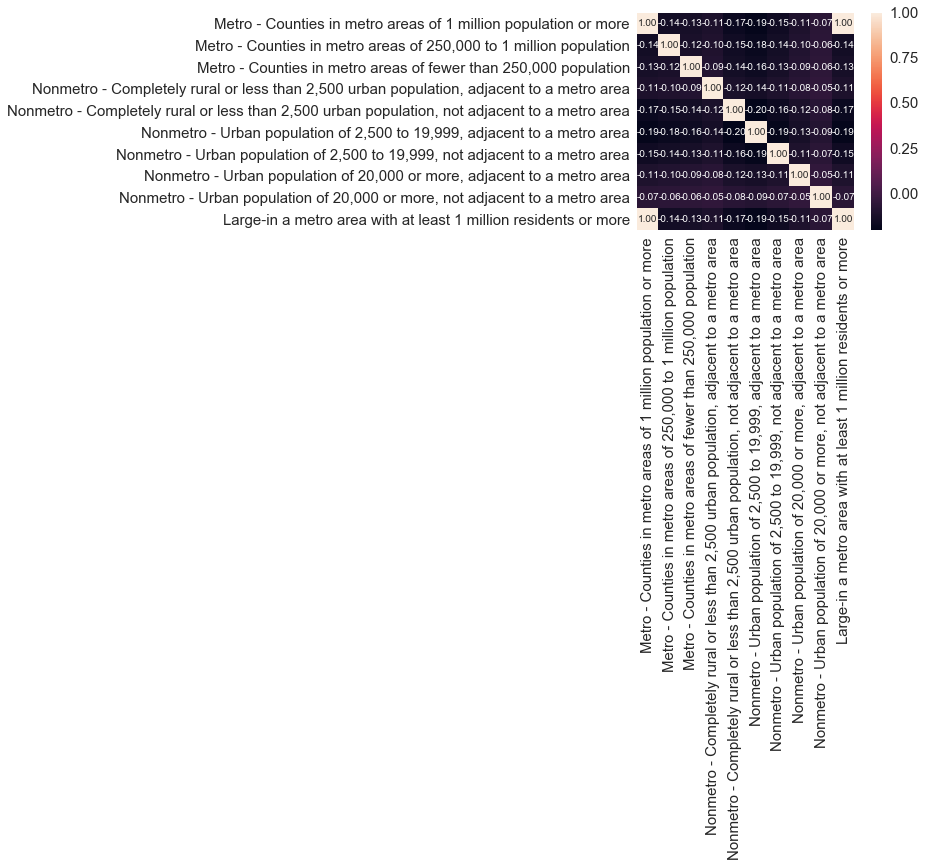

```python
## Visualize subset of correlation matrix (optional)

## get list of columns to be included in corr matrix
# list(c)
cols = ['Metro - Counties in metro areas of 1 million population or more',
 'Metro - Counties in metro areas of 250,000 to 1 million population',
 'Metro - Counties in metro areas of fewer than 250,000 population',
 'Nonmetro - Completely rural or less than 2,500 urban population, adjacent to a metro area',
 'Nonmetro - Completely rural or less than 2,500 urban population, not adjacent to a metro area',
 'Nonmetro - Urban population of 2,500 to 19,999, adjacent to a metro area',
 'Nonmetro - Urban population of 2,500 to 19,999, not adjacent to a metro area',
 'Nonmetro - Urban population of 20,000 or more, adjacent to a metro area',
 'Nonmetro - Urban population of 20,000 or more, not adjacent to a metro area',
 'Large-in a metro area with at least 1 million residents or more']

## create correlation matrix visualization
%matplotlib inline

import matplotlib.pyplot as plt
import seaborn as sns
import numpy as np
cm = np.corrcoef(c[cols].values.T)
sns.set(font_scale=1.5)
hm = sns.heatmap(cm,
            cbar=True,
            annot=True,
            square=True,
            fmt='.2f',
            annot_kws={'size': 10},
            yticklabels=cols,
            xticklabels=cols)


# plt.tight_layout()
import matplotlib.pyplot as plt
# plt.savefig('./figures/corr_mat.png', dpi=300)
plt.show()
```

```python
## drop perfectly correlated column
c=c.drop(['Large-in a metro area with at least 1 million residents or more'], axis=1)

c.shape
```

```
(3198, 56)
```

```python
## create threshold (mean) for testing accuracy of classification
c['above_mean_heart_disease_mortality_per_100k'] = np.where(c['heart_disease_mortality_per_100k'] > c.iloc[:,0].values.mean(), 1, 0)
```

#### Normalize Data

```python
#Transform to min/max normalization (0 to 1 range)
c = (c - c.min()) / (c.max() - c.min())

c.head(5)
```

|  | heart_disease_mortality_per_100k | econ__pct_civilian_labor | econ__pct_unemployment | econ__pct_uninsured_adults | econ__pct_uninsured_children | demo__pct_female | demo__pct_below_18_years_of_age | demo__pct_aged_65_years_and_older | demo__pct_hispanic | demo__pct_non_hispanic_african_american | ... | Noncore not adjacent to a metro/micro area and contains a town of 2,500 or more residents | Noncore not adjacent to a metro/micro area and does not contain a town of at least 2,500 residents | Small-in a metro area with fewer than 1 million residents | Farm-dependent | Federal/State government-dependent | Manufacturing-dependent | Mining-dependent | Nonspecialized | Recreation | above_mean_heart_disease_mortality_per_100k |
| --- | --- | --- | --- | --- | --- | --- | --- | --- | --- | --- | --- | --- | --- | --- | --- | --- | --- | --- | --- | --- | --- |
| 0 | 0.504 | 0.253 | 0.197 | 0.462 | 0.201 | 0.807 | 0.440 | 0.435 | 0.117 | 0.045 | ... | 0.000 | 0.000 | 1.000 | 0.000 | 0.000 | 1.000 | 0.000 | 0.000 | 0.000 | 1.000 |
| 1 | 0.367 | 0.440 | 0.122 | 0.476 | 0.487 | 0.763 | 0.554 | 0.186 | 0.440 | 0.082 | ... | 0.000 | 0.000 | 1.000 | 0.000 | 0.000 | 0.000 | 1.000 | 0.000 | 0.000 | 0.000 |
| 2 | 0.213 | 0.421 | 0.197 | 0.053 | 0.041 | 0.827 | 0.268 | 0.233 | 0.217 | 0.231 | ... | 0.000 | 0.000 | 0.000 | 0.000 | 0.000 | 0.000 | 0.000 | 1.000 | 0.000 | 0.000 |
| 3 | 0.270 | 0.369 | 0.214 | 0.349 | 0.175 | 0.837 | 0.332 | 0.395 | 0.014 | 0.057 | ... | 0.000 | 0.000 | 0.000 | 0.000 | 0.000 | 0.000 | 0.000 | 1.000 | 0.000 | 0.000 |
| 4 | 0.610 | 0.333 | 0.168 | 0.398 | 0.338 | 0.790 | 0.446 | 0.419 | 0.027 | 0.009 | ... | 1.000 | 0.000 | 0.000 | 0.000 | 0.000 | 0.000 | 0.000 | 1.000 | 0.000 | 1.000 |

5 rows × 57 columns